# CalfSMART microbiome

Sandeep Kumar

25/09/2020

This document presents the statistical analyses of the faecal bacterial community profiles and SCFA data generated from calves raised on three different allowances of milk replacer: 10% of initial bodyweight (LA), 20% of initial bodyweight (HA), and ad libitum (ADLIB). Faecal samples were collected at pre-weaning.

All data associated with analyses can be found here: ‘https://github.com/kusandeep/CalfSMART_microbiome’

# Libraries needed for analysis

# Read/prepare datasets

## Read main file, define factors and make subset of data

```r
### Bacterial Proportions
calfsmartdata = read.table("calfsmart_for_R_main.csv", header = T, sep = ",", stringsAsFactors = FALSE,check.names=FALSE)
dim(calfsmartdata)
```

```
## [1] 182 150
```

```r
for (k in 1:5) { calfsmartdata[,k] = as.factor(calfsmartdata[,k]) }

SCFA = colnames(calfsmartdata)[6:19]; length(SCFA)
```

```
## [1] 14
```

```r
Performance = colnames(calfsmartdata)[20:25]; length(Performance)
```

```
## [1] 6
```

```r
Period_diet_all = colnames(calfsmartdata)[26:34]; length(Period_diet_all)
```

```
## [1] 9
```

```r
Period_diet_week = colnames(calfsmartdata)[35:43]; length(Period_diet_week)
```

```
## [1] 9
```

```r
Bacteria = colnames(calfsmartdata)[44:ncol(calfsmartdata)]; length(Bacteria)
```

```
## [1] 107
```

```r
Period_All_Week = colnames(calfsmartdata)[26:43]; length(Period_All_Week)
```

```
## [1] 18
```

## Omit data/rows with missing values

SCFA data was not collected from all samples, thus the main calfsmartdata dataset has been subsetted to include only those with SCFA data.

```r
calfsmartdata_SCFA = droplevels(calfsmartdata[complete.cases(calfsmartdata),]); dim(calfsmartdata)
```

```
## [1] 182 150
```

```r
dim(calfsmartdata_SCFA)
```

```
## [1]  81 150
```

### Order the factor for Diets

```r
calfsmartdata$Diet <- factor(calfsmartdata$Diet  , levels=c("LA", "HA", "ADLIB"))
```

## Define colours for plots

```r
mycol1 = c("red","blue","green4","purple","darkorange", "cyan", "chartreuse")
```

## Choose subset data for analyses

This will later be needed for PCoA-analsysis

```r
FactorVars = c("Diet","Sampling_date",  "Antibiotic_bef_aft")

respVars = Bacteria; respV = "Bacteria" # choose this or below
#respVars = SCFA; respV = "SCFA"
```

## Subset by sampling date

This subsettingis needed to compare bacterial communities before and after antibiotic treatmants were administered

```r
sept28 = subset(calfsmartdata, calfsmartdata$Sampling_date =="2017-09-28")
oct5 = subset(calfsmartdata, calfsmartdata$Sampling_date == "2017-10-05")
oct12 = subset(calfsmartdata, calfsmartdata$Sampling_date == "2017-10-12")
oct19 = subset(calfsmartdata, calfsmartdata$Sampling_date == "2017-10-19")
oct30 = subset(calfsmartdata, calfsmartdata$Sampling_date == "2017-10-30")
nov7 = subset(calfsmartdata, calfsmartdata$Sampling_date == "2017-11-07")
nov16 = subset(calfsmartdata, calfsmartdata$Sampling_date == "2017-11-16")
```

### Generate dataset of samples before antibiotic treatment was administered

```r
calfsmartdata_befAb = rbind(sept28, oct5, oct12, oct19)
calfsmartdata_befAb$Sampling_date<-factor(calfsmartdata_befAb$Sampling_date)
```

### Generate dataset of samples after antibiotic treatment was administered

```r
calfsmartdata_aftAb = rbind(oct30, nov7, nov16)
calfsmartdata_aftAb$Sampling_date<-factor(calfsmartdata_aftAb$Sampling_date)
```

#Figure 1 - Barchart showing relative abundances of family-level taxa

Read data was extracted from Qiime 2.1 as “summarise taxon reads by samples”. Taxon data was converted to relative abundances within samples then mean and standard error of the mean(SEM) per treatment group were generated and plotted as a barchart in Excel.

# Alpha diversity statistics

Read data was extracted from Qiime 2.1 as “summarise taxon reads by samples”. Samples with less than 3,000 were omitted from analysis and this dataset was labelled “Reads for alpha diversity.csv

For alpha diversity Qiime 1.9 was used following instruction beow

### Convert otu table from txt format to biom format

biom convert -i otu_table.txt -o otu_table.biom –table-type “OTU table” –to-hdf5

### Perform alpha rarefaction using observed_species, Chao1, Shannon index at a max sampling depth of 3000, using 24 cores

alpha_rarefaction.py -i otu_table.biom -o alpha_3k/ -p alpha_param.txt -m -m otu_mapping.txt -e 3000 -a -O 24

## Differences in diversity across diet groups

Kruskal-Wallis testing was used to test significant difference between diet groups

```r
alpha_div = read.table("alpha_diversity.txt", header=T,sep="\t",stringsAsFactors = FALSE,check.names=TRUE)
dim(alpha_div)
```

```
## [1] 181   5
```

```r
str(alpha_div)
```

```
## 'data.frame':    181 obs. of  5 variables:
##  $ Calf.ID          : int  1 2 3 4 5 6 7 9 10 11 ...
##  $ Diet             : chr  "ADLIB" "HA" "LA" "ADLIB" ...
##  $ Farm             : chr  "Farmway" "Farmway" "Farmway" "Farmway" ...
##  $ Shannon.diversity: num  4.49 4.65 4.58 4.33 5.06 ...
##  $ Chao1.richness   : num  82.6 87.3 71.7 59.9 80.7 ...
```

```r
for (k in 1:3) { alpha_div[,k] = as.factor(alpha_div[,k]) }

alpha_div$Diet <- factor(alpha_div$Diet  , levels=c("LA", "HA", "ADLIB")) ### to order factors

### define colours for plots
mycol1 = c("red","blue","green4","purple","darkorange", "cyan", "chartreuse")

#### Kruskal-Wallis with pair-wise comparisions

res.kruskal_C <- alpha_div %>% kruskal_test(Chao1.richness ~ Diet)
res.kruskal_C
```

```
## # A tibble: 1 x 6
##   .y.                n statistic    df     p method
## * <chr>          <int>     <dbl> <int> <dbl> <chr>
## 1 Chao1.richness   181      3.73     2 0.155 Kruskal-Wallis
```

```r
res.kruskal_S <- alpha_div %>% kruskal_test(Shannon.diversity ~ Diet)
res.kruskal_S
```

```
## # A tibble: 1 x 6
##   .y.                   n statistic    df      p method
## * <chr>             <int>     <dbl> <int>  <dbl> <chr>
## 1 Shannon.diversity   181      11.0     2 0.0041 Kruskal-Wallis
```

### Figure 2 - Faecal bacterial alpha diversity of the milk replacer allowance groups Plot alpha diversity for Chao1 richness and Shannon diversity

Kruskal-wallis and Wilcoxon’s testwas used for pairwise comparision between diet groups

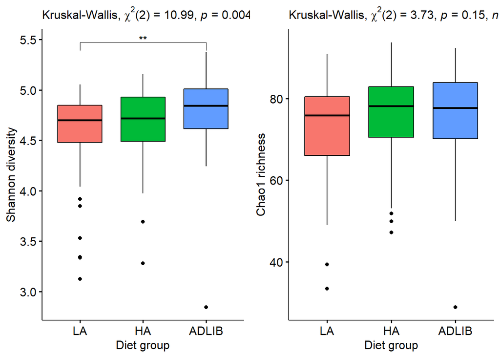

```r
pwc1 <- alpha_div %>%
  wilcox_test(Chao1.richness ~ Diet, p.adjust.method = "bonferroni")

pwc1 <- pwc1 %>% add_xy_position(x = "Diet")

p1 <- ggboxplot(alpha_div, x = "Diet", y = "Chao1.richness", fill = "Diet") +
  theme(legend.position = "none") +
  stat_pvalue_manual(pwc1, hide.ns = TRUE) +
  labs(y= "Chao1 richness", x = "Diet group",
       subtitle = get_test_label(res.kruskal_C, detailed = TRUE)) # remove this line to remove heading

pwc2 <- alpha_div %>%
  wilcox_test(Shannon.diversity ~ Diet, p.adjust.method = "bonferroni")

pwc2 <- pwc2 %>% add_xy_position(x = "Diet")

p2 <-  ggboxplot(alpha_div, x = "Diet", y = "Shannon.diversity", fill = "Diet") +
  theme(legend.position = "none") +
  stat_pvalue_manual(pwc2, hide.ns = TRUE) +
  labs(y= "Shannon diversity", x = "Diet group",
       subtitle = get_test_label(res.kruskal_S, detailed = TRUE)) # remove this line to remove heading

grid.arrange(p2, p1, ncol=2)
```

# ANOSIM analysis

Use appropriate factor(eg. Diet, Farm etc.) for different group observations

```r
anosim(calfsmartdata[,respVars], calfsmartdata$Diet)
```

```
##
## Call:
## anosim(x = calfsmartdata[, respVars], grouping = calfsmartdata$Diet)
## Dissimilarity: bray
##
## ANOSIM statistic R: 0.1306
##       Significance: 0.001
##
## Permutation: free
## Number of permutations: 999
```

```r
anosim(calfsmartdata[,respVars], calfsmartdata$Farm)
```

```
##
## Call:
## anosim(x = calfsmartdata[, respVars], grouping = calfsmartdata$Farm)
## Dissimilarity: bray
##
## ANOSIM statistic R: 0.001523
##       Significance: 0.375
##
## Permutation: free
## Number of permutations: 999
```

```r
anosim(calfsmartdata[,respVars], calfsmartdata$Sampling_date)
```

```
##
## Call:
## anosim(x = calfsmartdata[, respVars], grouping = calfsmartdata$Sampling_date)
## Dissimilarity: bray
##
## ANOSIM statistic R: 0.134
##       Significance: 0.001
##
## Permutation: free
## Number of permutations: 999
```

```r
anosim(calfsmartdata[,respVars], calfsmartdata$Antibiotic_bef_aft)
```

```
##
## Call:
## anosim(x = calfsmartdata[, respVars], grouping = calfsmartdata$Antibiotic_bef_aft)
## Dissimilarity: bray
##
## ANOSIM statistic R: 0.004225
##       Significance: 0.389
##
## Permutation: free
## Number of permutations: 999
```

```r
anosim(calfsmartdata_befAb[,respVars], calfsmartdata_befAb$Diet)
```

```
##
## Call:
## anosim(x = calfsmartdata_befAb[, respVars], grouping = calfsmartdata_befAb$Diet)
## Dissimilarity: bray
##
## ANOSIM statistic R: 0.1308
##       Significance: 0.001
##
## Permutation: free
## Number of permutations: 999
```

```r
anosim(calfsmartdata_befAb[,respVars], calfsmartdata_befAb$Farm)
```

```
##
## Call:
## anosim(x = calfsmartdata_befAb[, respVars], grouping = calfsmartdata_befAb$Farm)
## Dissimilarity: bray
##
## ANOSIM statistic R: 0.02523
##       Significance: 0.207
##
## Permutation: free
## Number of permutations: 999
```

```r
anosim(calfsmartdata_befAb[,respVars], calfsmartdata_befAb$Sampling_date)
```

```
##
## Call:
## anosim(x = calfsmartdata_befAb[, respVars], grouping = calfsmartdata_befAb$Sampling_date)
## Dissimilarity: bray
##
## ANOSIM statistic R: 0.1277
##       Significance: 0.001
##
## Permutation: free
## Number of permutations: 999
```

```r
anosim(calfsmartdata_aftAb[,respVars], calfsmartdata_aftAb$Diet)
```

```
##
## Call:
## anosim(x = calfsmartdata_aftAb[, respVars], grouping = calfsmartdata_aftAb$Diet)
## Dissimilarity: bray
##
## ANOSIM statistic R: 0.1966
##       Significance: 0.001
##
## Permutation: free
## Number of permutations: 999
```

```r
anosim(calfsmartdata_aftAb[,respVars], calfsmartdata_aftAb$Farm)
```

```
##
## Call:
## anosim(x = calfsmartdata_aftAb[, respVars], grouping = calfsmartdata_aftAb$Farm)
## Dissimilarity: bray
##
## ANOSIM statistic R: 0.01364
##       Significance: 0.342
##
## Permutation: free
## Number of permutations: 999
```

```r
anosim(calfsmartdata_aftAb[,respVars], calfsmartdata_aftAb$Sampling_date)
```

```
##
## Call:
## anosim(x = calfsmartdata_aftAb[, respVars], grouping = calfsmartdata_aftAb$Sampling_date)
## Dissimilarity: bray
##
## ANOSIM statistic R: 0.1938
##       Significance: 0.002
##
## Permutation: free
## Number of permutations: 999
```

## Beta dispersion check

```r
permutest(betadisper(vegdist(calfsmartdata[,respVars]), calfsmartdata$Diet, type = "median"))
```

```
##
## Permutation test for homogeneity of multivariate dispersions
## Permutation: free
## Number of permutations: 999
##
## Response: Distances
##            Df  Sum Sq   Mean Sq      F N.Perm Pr(>F)
## Groups      2 0.01375 0.0068731 0.5481    999  0.619
## Residuals 179 2.24444 0.0125388
```

```r
permutest(betadisper(vegdist(calfsmartdata[,respVars]), calfsmartdata$Farm, type = "median"))
```

```
##
## Permutation test for homogeneity of multivariate dispersions
## Permutation: free
## Number of permutations: 999
##
## Response: Distances
##            Df  Sum Sq   Mean Sq      F N.Perm Pr(>F)
## Groups      1 0.00241 0.0024073 0.1995    999  0.677
## Residuals 180 2.17159 0.0120644
```

```r
permutest(betadisper(vegdist(calfsmartdata[,respVars]), calfsmartdata$Sampling_date, type = "median"))
```

```
##
## Permutation test for homogeneity of multivariate dispersions
## Permutation: free
## Number of permutations: 999
##
## Response: Distances
##            Df  Sum Sq  Mean Sq      F N.Perm Pr(>F)
## Groups      6 0.14147 0.023578 1.8957    999   0.08 .
## Residuals 175 2.17659 0.012438
## ---
## Signif. codes:  0 '***' 0.001 '**' 0.01 '*' 0.05 '.' 0.1 ' ' 1
```

```r
permutest(betadisper(vegdist(calfsmartdata[,respVars]), calfsmartdata$Antibiotic_bef_aft, type = "median"))
```

```
##
## Permutation test for homogeneity of multivariate dispersions
## Permutation: free
## Number of permutations: 999
##
## Response: Distances
##            Df  Sum Sq  Mean Sq      F N.Perm Pr(>F)
## Groups      1 0.04106 0.041056 3.6373    999  0.045 *
## Residuals 180 2.03174 0.011287
## ---
## Signif. codes:  0 '***' 0.001 '**' 0.01 '*' 0.05 '.' 0.1 ' ' 1
```

```r
permutest(betadisper(vegdist(calfsmartdata_befAb[,respVars]), calfsmartdata_befAb$Diet, type = "median"))
```

```
##
## Permutation test for homogeneity of multivariate dispersions
## Permutation: free
## Number of permutations: 999
##
## Response: Distances
##            Df  Sum Sq   Mean Sq      F N.Perm Pr(>F)
## Groups      2 0.00869 0.0043471 0.3413    999  0.694
## Residuals 111 1.41379 0.0127368
```

```r
permutest(betadisper(vegdist(calfsmartdata_befAb[,respVars]), calfsmartdata_befAb$Farm, type = "median"))
```

```
##
## Permutation test for homogeneity of multivariate dispersions
## Permutation: free
## Number of permutations: 999
##
## Response: Distances
##            Df  Sum Sq   Mean Sq      F N.Perm Pr(>F)
## Groups      1 0.00527 0.0052721 0.4466    999  0.496
## Residuals 112 1.32222 0.0118055
```

```r
permutest(betadisper(vegdist(calfsmartdata_befAb[,respVars]), calfsmartdata_befAb$Sampling_date, type = "median"))
```

```
##
## Permutation test for homogeneity of multivariate dispersions
## Permutation: free
## Number of permutations: 999
##
## Response: Distances
##            Df  Sum Sq  Mean Sq      F N.Perm Pr(>F)
## Groups      3 0.05232 0.017440 1.3673    999  0.257
## Residuals 110 1.40308 0.012755
```

```r
permutest(betadisper(vegdist(calfsmartdata_aftAb[,respVars]), calfsmartdata_aftAb$Diet, type = "median"))
```

```
##
## Permutation test for homogeneity of multivariate dispersions
## Permutation: free
## Number of permutations: 999
##
## Response: Distances
##           Df  Sum Sq   Mean Sq      F N.Perm Pr(>F)
## Groups     2 0.00190 0.0009517 0.0887    999  0.952
## Residuals 65 0.69736 0.0107287
```

```r
permutest(betadisper(vegdist(calfsmartdata_aftAb[,respVars]), calfsmartdata_aftAb$Farm, type = "median"))
```

```
##
## Permutation test for homogeneity of multivariate dispersions
## Permutation: free
## Number of permutations: 999
##
## Response: Distances
##           Df  Sum Sq   Mean Sq     F N.Perm Pr(>F)
## Groups     1 0.00062 0.0006158 0.054    999  0.837
## Residuals 66 0.75287 0.0114071
```

```r
permutest(betadisper(vegdist(calfsmartdata_aftAb[,respVars]), calfsmartdata_aftAb$Sampling_date, type = "median"))
```

```
##
## Permutation test for homogeneity of multivariate dispersions
## Permutation: free
## Number of permutations: 999
##
## Response: Distances
##           Df  Sum Sq  Mean Sq      F N.Perm Pr(>F)
## Groups     2 0.02222 0.011112 0.9254    999  0.459
## Residuals 65 0.78055 0.012009
```

# Beta diversity

```r
# Compute (Bray-Curtis or Euclidean) distance between reps
if (respV == "Bacteria") { distObs <- vegdist(calfsmartdata[,respVars], method="bray") }
as.matrix(distObs)[1:5,1:5]
```

```
##           1         2         3         4         5
## 1 0.0000000 0.6149334 0.3517799 0.6014418 0.5935322
## 2 0.6149334 0.0000000 0.5822125 0.5542080 0.4401264
## 3 0.3517799 0.5822125 0.0000000 0.5858340 0.5199577
## 4 0.6014418 0.5542080 0.5858340 0.0000000 0.3989782
## 5 0.5935322 0.4401264 0.5199577 0.3989782 0.0000000
```

```r
### PCoA
Calf.pco <- pcoa(distObs)
summary(Calf.pco$values) # check for negative eigenvalues
```

```
##   Eigenvalues         Relative_eig         Rel_corr_eig       Broken_stick
##  Min.   :-0.201796   Min.   :-0.0085863   Min.   :0.000000   Min.   :0.000000
##  1st Qu.:-0.030645   1st Qu.:-0.0013039   1st Qu.:0.002841   1st Qu.:0.001562
##  Median : 0.003709   Median : 0.0001578   Median :0.003424   Median :0.003805
##  Mean   : 0.129132   Mean   : 0.0054945   Mean   :0.005495   Mean   :0.005495
##  3rd Qu.: 0.080352   3rd Qu.: 0.0034189   3rd Qu.:0.004700   3rd Qu.:0.007625
##  Max.   : 5.870810   Max.   : 0.2497995   Max.   :0.101164   Max.   :0.032072
##   Cum_corr_eig    Cumul_br_stick
##  Min.   :0.1012   Min.   :0.03207
##  1st Qu.:0.5813   1st Qu.:0.60404
##  Median :0.7588   Median :0.85091
##  Mean   :0.7229   Mean   :0.75412
##  3rd Qu.:0.8999   3rd Qu.:0.96783
##  Max.   :1.0000   Max.   :1.00000
```

```r
barplot(Calf.pco$values$Relative_eig[1:5]) # to check where is the maxim variation
```

[output not shown]

```r
pcopct = round(100*Calf.pco$values[,3],2)
pcokeep = length(pcopct[pcopct>10]) # keep PCs with >10%
if (pcokeep<2) { pcokeep=2 }
Yid = as.numeric(calfsmartdata$Diet); table(Yid)
```

```
## Yid
##  1  2  3
## 64 57 61
```

```r
PCOdata = data.frame(Calf.pco$vectors[,1:10],Yid,calfsmartdata[,FactorVars]); head(PCOdata)
```

```
##        Axis.1      Axis.2      Axis.3       Axis.4      Axis.5       Axis.6
## 1 -0.09906806  0.12108161 -0.22081704 -0.023753842 -0.08109150 -0.002326012
## 2 -0.40118426 -0.06360284 -0.01168269 -0.001911205  0.01451923  0.198698405
## 3 -0.19732016  0.19903155 -0.10235292 -0.035457224 -0.03826311 -0.051863985
## 4 -0.32176421 -0.22426659  0.02605761 -0.076180124  0.03649259  0.113952300
## 5 -0.40117426 -0.14051523  0.03351744 -0.027045993  0.01083913  0.086070742
## 6 -0.07734871  0.05633490 -0.25272378  0.008193742  0.09007958  0.039910089
##         Axis.7       Axis.8      Axis.9     Axis.10 Yid  Diet Sampling_date
## 1  0.002755136 -0.022721898  0.10059432 -0.01936829   3 ADLIB    2017-09-28
## 2 -0.085433961 -0.139392804 -0.10524219  0.10150581   3 ADLIB    2017-09-28
## 3 -0.033434229  0.062037263 -0.04796525 -0.02591353   3 ADLIB    2017-09-28
## 4  0.021825858 -0.061133780  0.01008353 -0.09212268   3 ADLIB    2017-09-28
## 5 -0.055721560 -0.061531628 -0.08051665 -0.04436501   3 ADLIB    2017-09-28
## 6  0.018581256 -0.005971339  0.07025311 -0.01619699   3 ADLIB    2017-09-28
##   Antibiotic_bef_aft
## 1             Pre_AB
## 2             Pre_AB
## 3             Pre_AB
## 4             Pre_AB
## 5             Pre_AB
## 6             Pre_AB
```

## Figure 3 - PCoA of faecal bacterial communities (graph using values from above)

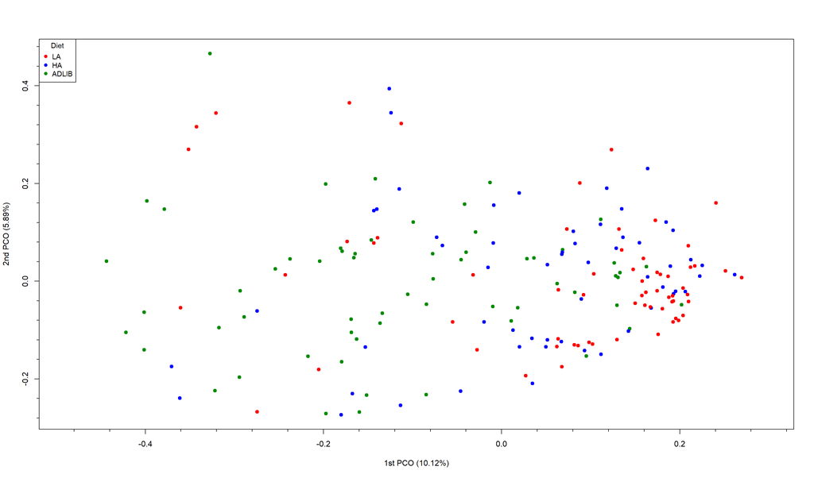

```r
xlim1 = 1.1*range(PCOdata[,1])
xlab1 = paste("1st PCO (",pcopct[1],"%)",sep=""); ylab1 = paste("2nd PCO (",pcopct[2],"%)",sep="")
plot(PCOdata[,1:2], pch=19, xlim=xlim1,
     xlab=xlab1, ylab=ylab1, col=mycol1[calfsmartdata$Diet])
minor.tick(nx=5,ny=5)
legend("topleft", bty="o", pch=19, cex=0.9, pt.cex=0.9, x.intersp=1, col=mycol1, horiz=F,
       legend=levels(calfsmartdata$Diet), title="Diet")
```

# Canonical correlation using spls function from mixOmics

```r
#### For Bacteria vs intakes
X <- calfsmartdata[,Bacteria]
dim(X)
```

```
## [1] 182 107
```

```r
Y <- calfsmartdata[,Period_All_Week]
dim(Y)
```

```
## [1] 182  18
```

```r
####FOR SCFA Vs bacteria
X_SCFA <- calfsmartdata_SCFA[,Bacteria]
Y_SCFA <- calfsmartdata_SCFA[,SCFA]


####FOR performance data Vs bacteria
X_perf <- calfsmartdata[,Bacteria]
Y_perf <- calfsmartdata[,Performance]

####FOR SCFA Vs intakes
X_SCFA_int <- calfsmartdata_SCFA[,SCFA]
Y_SCFA_int <- calfsmartdata_SCFA[,Period_All_Week]

###FOR SCFA Vs performance
X_SCFA_perf <- calfsmartdata_SCFA[,SCFA]
Y_SCFA_perf <- calfsmartdata_SCFA[,Performance]
```

## spls mode of canonical correlation

```r
calfsmart.res <- spls(X, Y, ncomp = 3, mode="canonical")
calfsmart_SCFA.res <- spls(X_SCFA, Y_SCFA, ncomp = 3, mode="canonical")
calfsmart_perf.res <- spls(X_perf, Y_perf, ncomp = 3, mode="canonical")
calfsmart_SCFA_int.res <- spls(X_SCFA_int, Y_SCFA_int, ncomp = 3, mode="canonical")
calfsmart_SCFA_perf.res <- spls(X_SCFA_perf, Y_SCFA_perf, ncomp = 3, mode="canonical")
```

## Generate CIM values and plot

```r
cim_periods <- cim(calfsmart.res, margins = c(16, 16), threshold = 0.30, transpose = T,
                  row.cex = 0.8, col.cex = 0.8, keysize=c(1,0.7))
```

[output not shown]

```r
cim_SCFA <- cim(calfsmart_SCFA.res, margins = c(16, 16),threshold = 0.25, transpose = T,
                   row.cex = 0.8, col.cex = 0.8, keysize=c(1,0.7))
```

[output not shown]

```r
cim_Performance <- cim(calfsmart_perf.res, margins = c(16, 16), threshold = 0.25, transpose = T,
                   row.cex = 0.8, col.cex = 0.8, keysize=c(1,0.7))
```

[output not shown]

```r
cim_SCFA_int <- cim(calfsmart_SCFA_int.res, margins = c(16, 16), threshold = 0.30, transpose = T,
                  row.cex = 1.2, col.cex = 1.2, keysize=c(1,0.7))
```

[output not shown]

```r
cim_SCFA_perf <- cim(calfsmart_SCFA_perf.res, margins = c(16, 16), threshold = 0.30, transpose = T,
                  row.cex = 1.2, col.cex = 1.2, keysize=c(1,0.7))
```

[output not shown]

Print/save CIM values for from above and pest abundance data by different diet groups for heatmap generation.

```r
#write.table(cim_periods$mat,file="bacteria_vs_periods.txt",sep="\t") #Period_All_Week
#write.table(cim_SCFA$mat,file="bacteria_vs_scfa.txt",sep="\t") #SCFA
#write.table(cim_Performance$mat,file="bacteria_vs_performance.txt",sep="\t") #Performance
#write.table(cim_SCFA_int$mat,file="SCFA_vs_intake.txt",sep="\t")
#write.table(cim_SCFA_perf$mat,file="SCFA_vs_performance.txt",sep="\t")
```

Modified files have been provided for convenience

#Heatmaps using CIM values and abundance; figure 4, 5 and 6

CIM values form above were used to generate heatmaps with bacterial abundance

## Figure 4 - Correlation heatmap between bacterial community composition and calf dietary intakes

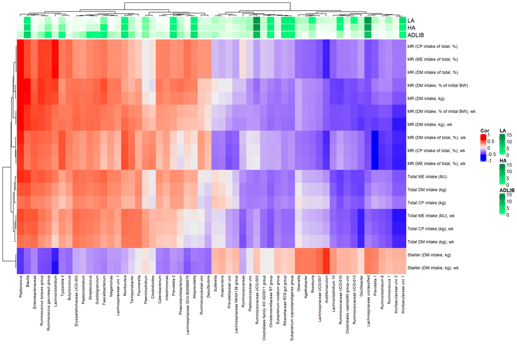

```r
heatmap_periods.data <- read.table("bacteria_vs_periods.txt",header=T,sep="\t",stringsAsFactors = FALSE,check.names=FALSE)
#using check.names=FALSE can keep the column name as it but then can't use $ function to detect the column
rownames(heatmap_periods.data) <- heatmap_periods.data[,1] # keep the taxon name as it is. No space replaced by .

#define colour
col_fun = colorRamp2(c(0, 1,3,7, 13), c("white", "springgreen","springgreen2","springgreen3","springgreen4"))

####Print heatmap
#pdf("heatmap_fig4.pdf", height=6, width=12, pointsize=6)
column_ha = HeatmapAnnotation(LA = heatmap_periods.data[,20], HA = heatmap_periods.data[,21],  ADLIB = heatmap_periods.data[,22],
                              col = list(LA = col_fun, HA = col_fun, ADLIB = col_fun), show_legend = T,  show_annotation_name = T)
Heatmap(t(as.matrix(heatmap_periods.data[,2:19])), name = "Cor", top_annotation = column_ha, column_names_gp = gpar(fontsize = 8),
        row_names_gp = gpar(fontsize = 9), show_heatmap_legend = T)
```

## Figure 5 - Correlation heatmap between bacterial community composition and SCFA profiles

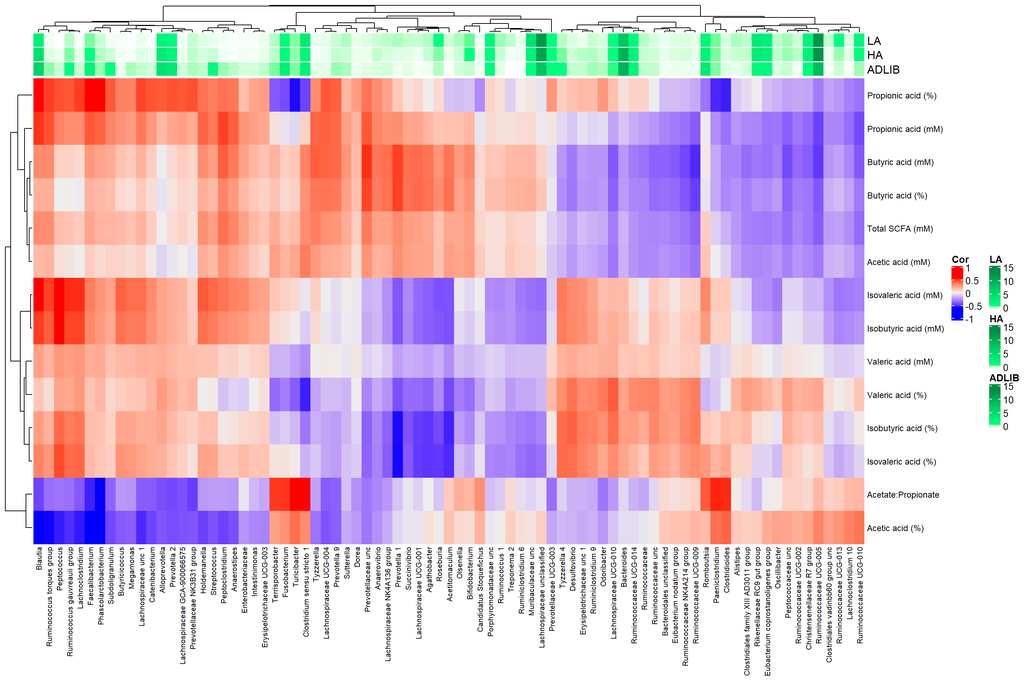

```r
heatmap_scfa.data <- read.table("bacteria_vs_scfa.txt",header=T,sep="\t",stringsAsFactors = FALSE,check.names=FALSE)
#using check.names=FALSE can keep the column name as it but then can't use $ function to detect the column
rownames(heatmap_scfa.data) <- heatmap_scfa.data[,1] # keep the taxon name as it is. No space replaced by .

#define colour
col_fun = colorRamp2(c(0, 1,3,7, 13), c("white", "springgreen","springgreen2","springgreen3","springgreen4"))

####Print heatmap
#pdf("heatmap_fig5.pdf", height=6, width=12, pointsize=6)
column_ha = HeatmapAnnotation(LA = heatmap_scfa.data[,16], HA = heatmap_scfa.data[,17],  ADLIB = heatmap_scfa.data[,18],
                              col = list(LA = col_fun, HA = col_fun, ADLIB = col_fun), show_legend = T,  show_annotation_name = T)
Heatmap(t(as.matrix(heatmap_scfa.data[,2:15])), name = "Cor", top_annotation = column_ha, column_names_gp = gpar(fontsize = 8), row_names_gp = gpar(fontsize = 9), show_heatmap_legend = T)
```

## Figure 6 - Correlation heatmap between bacterial community composition and calf performance data

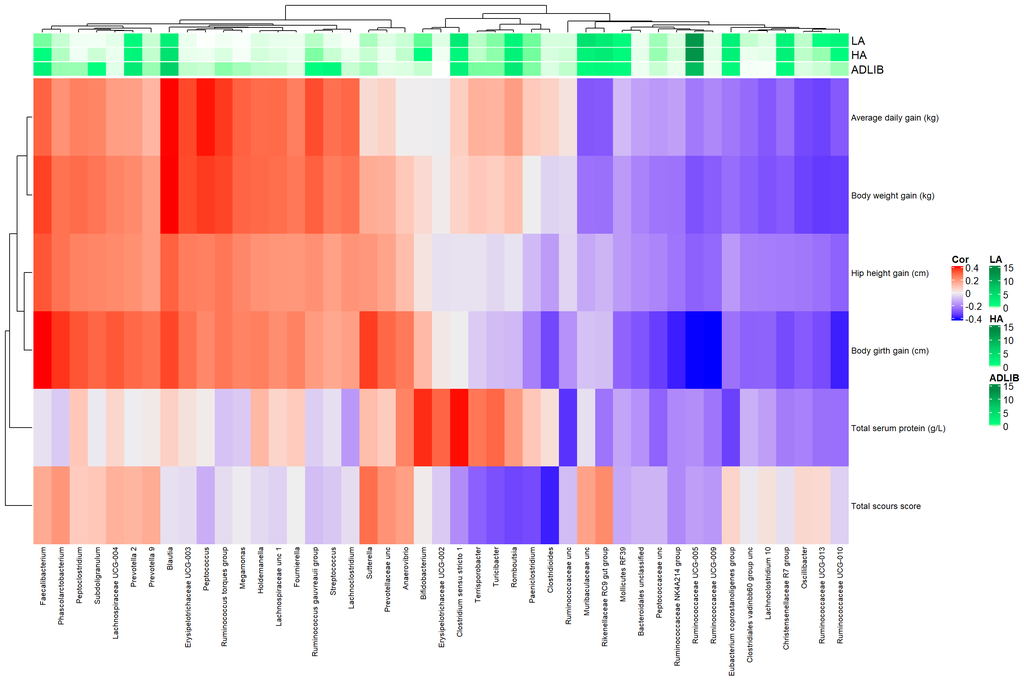

```r
heatmap_performance.data <- read.table("bacteria_vs_performance.txt",header=T,sep="\t",stringsAsFactors = FALSE,check.names=FALSE)
#using check.names=FALSE can keep the column name as it but then can't use $ function to detect the column
rownames(heatmap_performance.data) <- heatmap_performance.data[,1] # keep the taxon name as it is. No space replaced by .

#define colour
col_fun = colorRamp2(c(0, 1,3,7, 13), c("white", "springgreen","springgreen2","springgreen3","springgreen4"))

####Print heatmap
#pdf("heatmap_fig6.pdf", height=6, width=12, pointsize=6)
column_ha = HeatmapAnnotation(LA = heatmap_performance.data[,8], HA = heatmap_performance.data[,9],  ADLIB = heatmap_performance.data[,10],
                              col = list(LA = col_fun, HA = col_fun, ADLIB = col_fun), show_legend = T,  show_annotation_name = T)
Heatmap(t(as.matrix(heatmap_performance.data[,2:7])), name = "Cor", top_annotation = column_ha, column_names_gp = gpar(fontsize = 8),
        row_names_gp = gpar(fontsize = 9), show_heatmap_legend = T)
```

#Supplementary figures

## Figure S1- PCoA by Farm

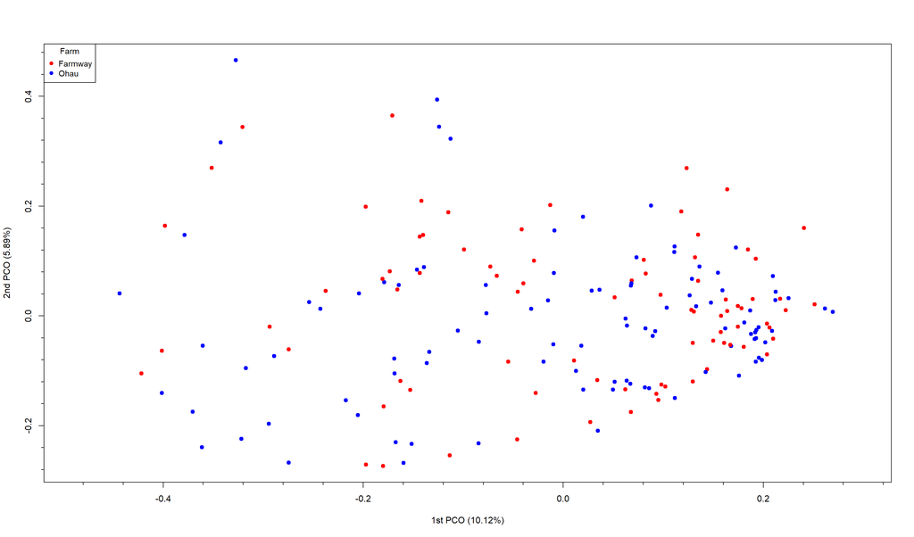

```r
xlim1 = 1.1*range(PCOdata[,1])
xlab1 = paste("1st PCO (",pcopct[1],"%)",sep=""); ylab1 = paste("2nd PCO (",pcopct[2],"%)",sep="")
plot(PCOdata[,1:2], pch=19, xlim=xlim1,
     xlab=xlab1, ylab=ylab1, col=mycol1[calfsmartdata$Farm])
minor.tick(nx=5,ny=5)
legend("topleft", bty="o", pch=19, cex=0.9, pt.cex=0.9, x.intersp=1, col=mycol1, horiz=F,
       legend=levels(calfsmartdata$Farm), title="Farm")
```

## Figure S1- PCoA by Sampling date

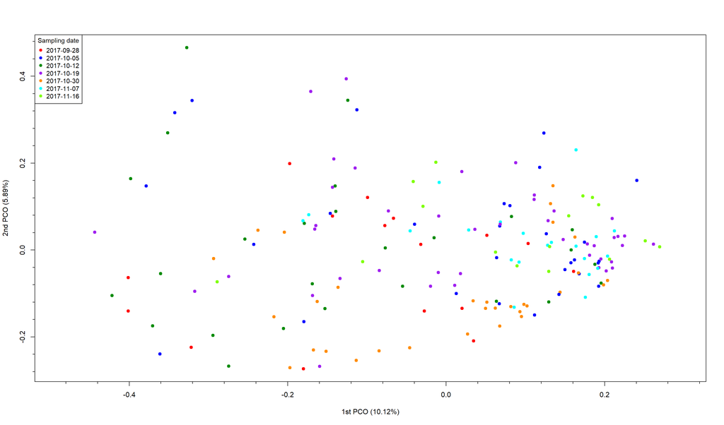

```r
xlim1 = 1.1*range(PCOdata[,1])
xlab1 = paste("1st PCO (",pcopct[1],"%)",sep=""); ylab1 = paste("2nd PCO (",pcopct[2],"%)",sep="")
plot(PCOdata[,1:2], pch=19, xlim=xlim1,
     xlab=xlab1, ylab=ylab1, col=mycol1[calfsmartdata$Sampling_date])
minor.tick(nx=5,ny=5)
legend("topleft", bty="o", pch=19, cex=0.9, pt.cex=0.9, x.intersp=1, col=mycol1, horiz=F,
       legend=levels(calfsmartdata$Sampling_date), title="Sampling date")
```

## Figure S2 Variation in calf milk replacer intakes

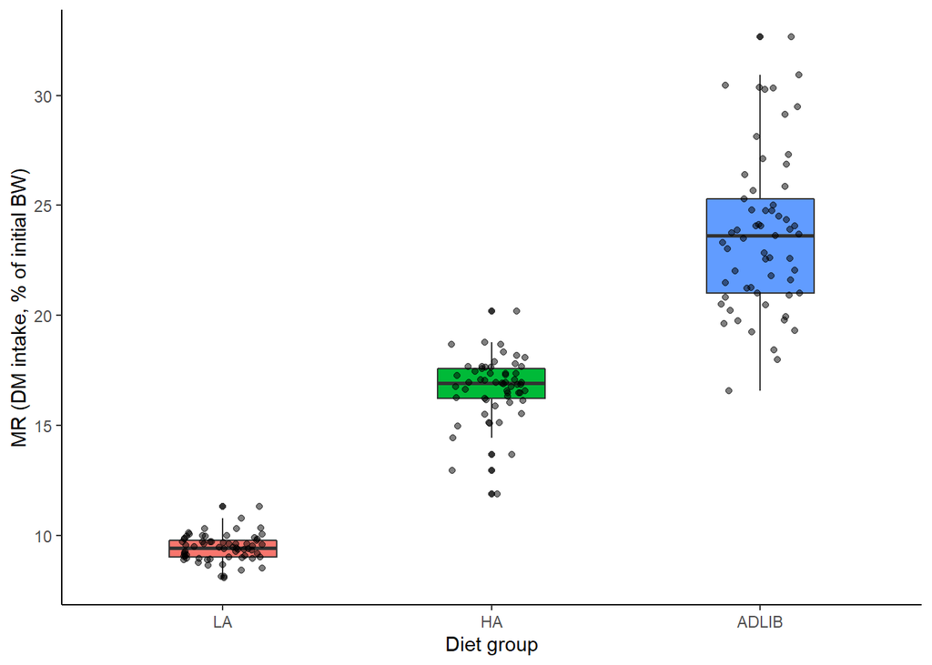

```r
ggplot(calfsmartdata, aes(x=calfsmartdata$Diet, y=calfsmartdata$`MR (DM intake, % of initial BW)`, fill = Diet)) +
  geom_boxplot(width = 0.4, show.legend = FALSE) + geom_jitter(alpha = 1/2, width = 0.15) +
  theme_classic() + theme(legend.position = "none") + labs(y= "MR (DM intake, % of initial BW)", x = "Diet group")
```

## Figure S3 - Correlation heatmap between SCFA profiles and calf dietary intakes

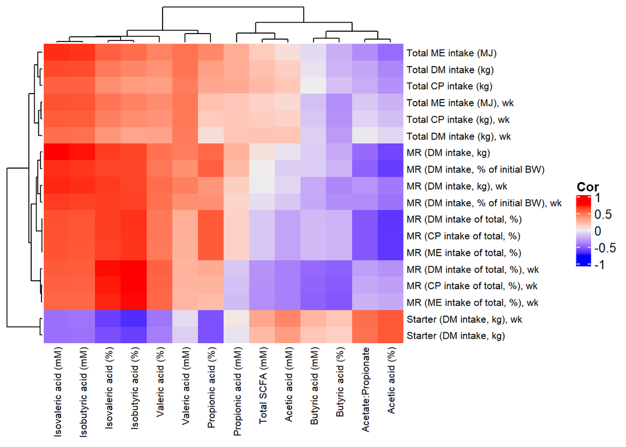

```r
heatmap_scfa_intake.data <- read.table("SCFA_vs_intake.txt",header=T,sep="\t", stringsAsFactors = FALSE,check.names=FALSE)
rownames(heatmap_scfa_intake.data) <- heatmap_scfa_intake.data[,1]
####Print heatmap
#pdf("Figure_S3.pdf", height=6, width=8, pointsize=6)
Heatmap(t(as.matrix(heatmap_scfa_intake.data[,2:19])), name = "Cor", column_names_gp = gpar(fontsize = 8),
        row_names_gp = gpar(fontsize = 8), show_heatmap_legend = T)
```

## Figure S4 - Correlation heatmap between SCFA profiles and calf performance data

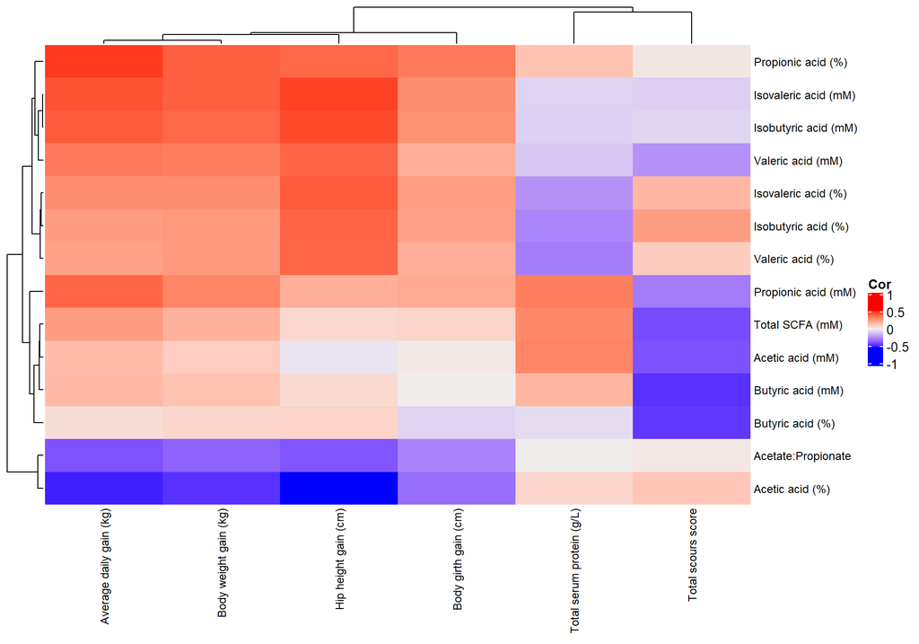

```r
heatmap_scfa_performance.data <- read.table("SCFA_vs_performance.txt",header=T,sep="\t", stringsAsFactors = FALSE,check.names=FALSE)
rownames(heatmap_scfa_performance.data) <- heatmap_scfa_performance.data[,1]
####Print heatmap
#pdf("Figure_S4.pdf", height=6, width=6, pointsize=6)
Heatmap(t(as.matrix(heatmap_scfa_performance.data[,2:15])), name = "Cor", column_names_gp = gpar(fontsize = 9),
        row_names_gp = gpar(fontsize = 9), show_heatmap_legend = T)
```